# Exploring the BRFSS data

## Setup

### Load packages

```r
library(ggplot2)
library(dplyr)
```

### Load data

```r
load("brfss2013.RData")
```

## Part 1: Data

The Behavioral Risk Factor Surveillance System (BRFSS) is a collaborative project between all of the states in the United States (US) and participating US territories and the Centers for Disease Control and Prevention (CDC). The BRFSS is administered and supported by CDC’s Population Health Surveillance Branch, under the Division of Population Health at the National Center for Chronic Disease Prevention and Health Promotion. BRFSS is an ongoing surveillance system designed to measure behavioral risk factors for the non-institutionalized adult population (18 years of age and older) residing in the US.

The BRFSS objective is to collect uniform, state-specific data on preventive health practices and risk behaviors that are linked to chronic diseases, injuries, and preventable infectious diseases that affect the adult population

[Source: http://www.cdc.gov/brfss/annual_data/2013/pdf/Overview_2013.pdf]

## Part 2: Research questions

**Research quesion 1:** As the first question, I’d like to explore if there is any relationship between the people who have been told they have high blood cholestrol and their age. I’d also check if there is any variation in the relationship between the variables in context, for Males and Females. The variables I’ll be looking at are  
- **toldhi2** - Ever Told Blood Cholesterol High (Main Survey - Section 6)  
- **_ageg5yr** - Reported Age In Five-Year Age Categories Calculated Variable (Calculated Variables)  
- **sex** - Respondents Sex (Main Survey - Section 8)

*Personal interest in the question* : I’m a lean person but my dad is quite stout. Even though he hasn’t been told he has high blood cholestrol yet, many people of my dad’s age (around 50) look overweight. My dad says he was lean when he was my age(20). I want to know at what most people have high blood cholestrol.  
**Research quesion 2:** As the second question, I’d like to explore if there is any relationship between the general health of people and if people did any exercise in past 30 days. I’d again check if there is any variation in the relationship between the variables in context, for Males and Females. The variables I’ll be looking at are  
- **genhlth** - General Health (Main Survey - Section 1)  
- **exerany2** - Exercise In Past 30 Days (Main Survey - Section 12)  
- **sex** - Respondents Sex (Main Survey - Section 8)

*Personal interest in the question* : These days young people are going crazy about exercise and being tight and fit. I want to know how exercise effects our general health.

**Research quesion 3:** As the final question, I’d like to find how many people that have been told they have high blood cholestrol have been ever diagnosed with a heart attack. Also, among these people, how many smoked at least 100 so far? The variables in context are  
- **toldhi2** - Ever Told Blood Cholesterol High (Main Survey - Section 6)  
- **cvdinfr4** - Ever Diagnosed With Heart Attack (Main Survey - Section 7)  
- **smoke100** - Smoked At Least 100 Cigarettes (Main Survey - Section 9)

*Personal interest in the question* : Again, high blood cholestrol is a very significant problem these days leading to heart attacks. Also, smoking also results in bad effects on the heart. I want to know how blood cholestrol, smoking and heart attacks relate to each other. * * *

## Part 3: Exploratory data analysis

**Research quesion 1:**

To start off, data that is relevant to the question is filtered into a new Dataset called “BAndA”(Blood Cholestrol and Age). NA’s are filtered out. In the filter function “toldhi2 ==”Yes" " is used to take only records of people who have been told they have high blood cholestrol.

```r
BAndA <- brfss2013 %>%
  filter(!is.na(toldhi2) & !is.na(X_ageg5yr) & toldhi2 == "Yes") %>%
  group_by(toldhi2, X_ageg5yr) %>%
  summarise(count=n())
```

A look at the BAndA Dataset:

```r
BAndA
```

```
## Source: local data frame [13 x 3]
## Groups: toldhi2 [?]
##
##    toldhi2       X_ageg5yr count
##     <fctr>          <fctr> <int>
## 1      Yes    Age 18 to 24  1058
## 2      Yes    Age 25 to 29  1661
## 3      Yes    Age 30 to 34  3207
## 4      Yes    Age 35 to 39  5018
## 5      Yes    Age 40 to 44  7552
## 6      Yes    Age 45 to 49 11206
## 7      Yes    Age 50 to 54 17827
## 8      Yes    Age 55 to 59 23203
## 9      Yes    Age 60 to 64 27078
## 10     Yes    Age 65 to 69 27268
## 11     Yes    Age 70 to 74 21947
## 12     Yes    Age 75 to 79 16133
## 13     Yes Age 80 or older 18765
```

Now a scattered plot is plotted using the age variable on X-axis and count on Y-axis.

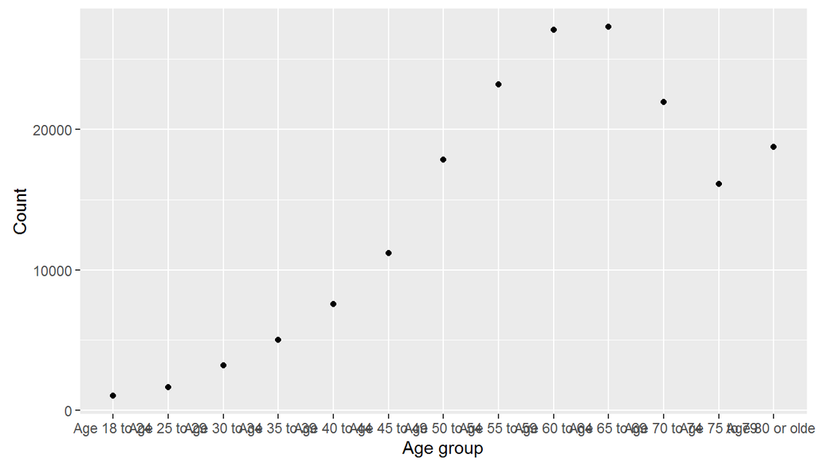

```r
ggplot(data=BAndA, aes(x=X_ageg5yr, y = count)) +  geom_point() + xlab("Age group") + ylab("Count")
```

Now, for the extension, similar graphs are plotted for Males and Females. Firstly, data is filtered further more using “sex ==”Male" " & “sex ==”Female" " to get two datasets one containing only Male records and the other containing Female records.

```r
BAndAMale <- brfss2013 %>%
   filter(!is.na(toldhi2) & !is.na(X_ageg5yr) & toldhi2 == "Yes" & sex == "Male") %>%
   group_by(toldhi2, X_ageg5yr) %>%
   summarise(count=n())
```

The data corresponding to Males looks like:

```r
BAndAMale
```

```
## Source: local data frame [13 x 3]
## Groups: toldhi2 [?]
##
##    toldhi2       X_ageg5yr count
##     <fctr>          <fctr> <int>
## 1      Yes    Age 18 to 24   511
## 2      Yes    Age 25 to 29   820
## 3      Yes    Age 30 to 34  1533
## 4      Yes    Age 35 to 39  2453
## 5      Yes    Age 40 to 44  3835
## 6      Yes    Age 45 to 49  5371
## 7      Yes    Age 50 to 54  7976
## 8      Yes    Age 55 to 59  9762
## 9      Yes    Age 60 to 64 11206
## 10     Yes    Age 65 to 69 11097
## 11     Yes    Age 70 to 74  8318
## 12     Yes    Age 75 to 79  5604
## 13     Yes Age 80 or older  5927
```

And the graph looks like:

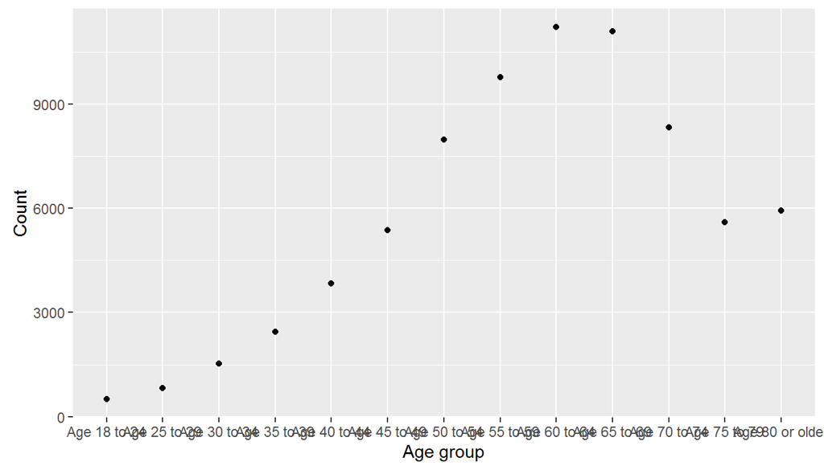

```r
ggplot(data=BAndAMale, aes(x=X_ageg5yr, y = count)) +  geom_point() + xlab("Age group") + ylab("Count")
```

Now for females,

```r
BAndAFemale <- brfss2013 %>%
   filter(!is.na(toldhi2) & !is.na(X_ageg5yr) & toldhi2 == "Yes" & sex == "Female") %>%
   group_by(toldhi2, X_ageg5yr) %>%
   summarise(count=n())

BAndAFemale
```

```
## Source: local data frame [13 x 3]
## Groups: toldhi2 [?]
##
##    toldhi2       X_ageg5yr count
##     <fctr>          <fctr> <int>
## 1      Yes    Age 18 to 24   547
## 2      Yes    Age 25 to 29   841
## 3      Yes    Age 30 to 34  1674
## 4      Yes    Age 35 to 39  2565
## 5      Yes    Age 40 to 44  3717
## 6      Yes    Age 45 to 49  5835
## 7      Yes    Age 50 to 54  9851
## 8      Yes    Age 55 to 59 13441
## 9      Yes    Age 60 to 64 15872
## 10     Yes    Age 65 to 69 16171
## 11     Yes    Age 70 to 74 13629
## 12     Yes    Age 75 to 79 10529
## 13     Yes Age 80 or older 12838
```

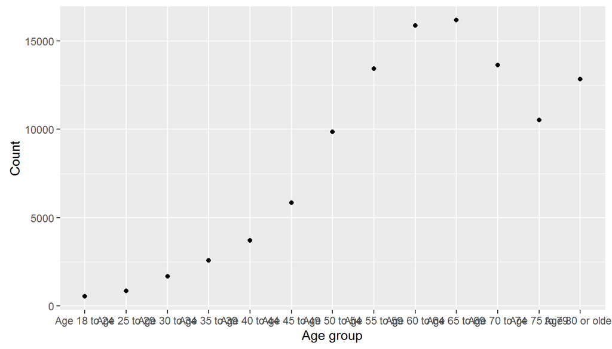

```r
ggplot(data=BAndAFemale, aes(x=X_ageg5yr, y = count)) +  geom_point() + xlab("Age group") + ylab("Count")
```

We can see that there is no real difference in the trend and that **In all the cases the highest number of people satisfying the criteria are in the age group 60-70**

**Research quesion 2:** Again to start off, the data relevant to the research question is filtered into a dataset called *hAndE* (Health and Exercise). NAs are filtered out.

```r
hAndE <- brfss2013 %>%
  filter(!is.na(genhlth) & !is.na(exerany2)) %>%
  group_by(genhlth, exerany2) %>%
  summarise(count=n())
```

The dataset *hAndE* looks like:

```r
hAndE
```

```
## Source: local data frame [10 x 3]
## Groups: genhlth [?]
##
##      genhlth exerany2  count
##       <fctr>   <fctr>  <int>
## 1  Excellent      Yes  67914
## 2  Excellent       No  11453
## 3  Very good      Yes 120595
## 4  Very good       No  28860
## 5       Good      Yes  97095
## 6       Good       No  42443
## 7       Fair      Yes  34844
## 8       Fair       No  26949
## 9       Poor      Yes  10941
## 10      Poor       No  14856
```

A bar graph is plotted with exerany2 on x-axis and count on y-axis. The genhlth variable is used as fill, with 5 colours.

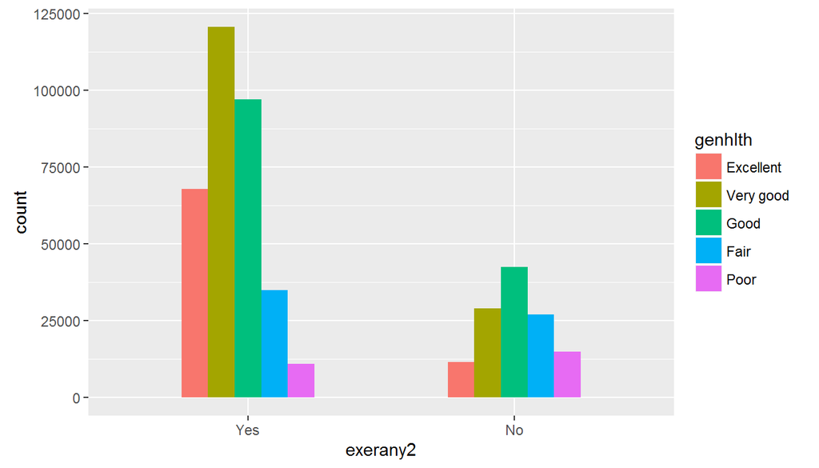

```r
ggplot(data = hAndE, aes(x=exerany2, y=count, fill=genhlth)) + geom_bar(stat="identity", width = 0.5, position="dodge")
```

Though this graph shows that there are more people with good health on the yes side of exerany2, it is still not the perfect way to represent the data, as the counts for each category of genhlth are not the same.

To get a clearer picture, proportions can be calculated, and then graphs can be plotted.

```r
hAndE <- hAndE %>%
  group_by(genhlth) %>%
  mutate(total=sum(count))

hAndE <- hAndE %>%
  mutate(prop=count/total)
```

After calculating the proportions the dataset will look like:

```r
hAndE
```

```
## Source: local data frame [10 x 5]
## Groups: genhlth [5]
##
##      genhlth exerany2  count  total      prop
##       <fctr>   <fctr>  <int>  <int>     <dbl>
## 1  Excellent      Yes  67914  79367 0.8556957
## 2  Excellent       No  11453  79367 0.1443043
## 3  Very good      Yes 120595 149455 0.8068984
## 4  Very good       No  28860 149455 0.1931016
## 5       Good      Yes  97095 139538 0.6958320
## 6       Good       No  42443 139538 0.3041680
## 7       Fair      Yes  34844  61793 0.5638826
## 8       Fair       No  26949  61793 0.4361174
## 9       Poor      Yes  10941  25797 0.4241191
## 10      Poor       No  14856  25797 0.5758809
```

Now, similar graph can be plotted, with exerany2 on x-axis and genhlth as fill, but this time with proportions on y-axis. The graph looks like:

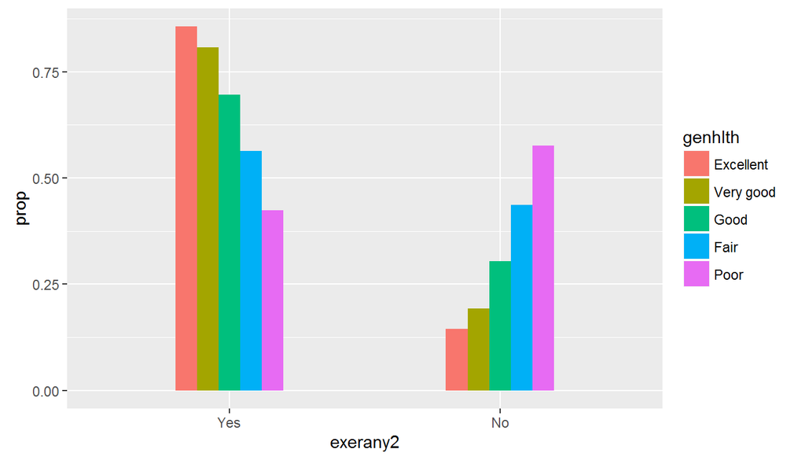

```r
ggplot(hAndE, aes(x=exerany2, y=prop, fill=genhlth)) + geom_bar(stat="identity", width=0.4, position="dodge")
```

It can be seen that a large proportion of people with Excellent, Very good, Good health are on the “Yes” side of exerany2. Also, the “No” side has a large proportion of people with “Poor” health. We can conclude that there is a positive relationship between exercise in the past 30 days and the general health of a person.

Similar calculations can be done for Male and Female records and graphs can be plotted in a similar way.

```r
hAndEMale<- brfss2013 %>%
  filter(!is.na(genhlth) & !is.na(exerany2) & sex == "Male") %>%
  group_by(genhlth, exerany2, sex) %>%
  summarise(count=n())

hAndEMale
```

```
## Source: local data frame [10 x 4]
## Groups: genhlth, exerany2 [?]
##
##      genhlth exerany2    sex count
##       <fctr>   <fctr> <fctr> <int>
## 1  Excellent      Yes   Male 28193
## 2  Excellent       No   Male  4816
## 3  Very good      Yes   Male 49918
## 4  Very good       No   Male 11075
## 5       Good      Yes   Male 42080
## 6       Good       No   Male 16096
## 7       Fair      Yes   Male 14474
## 8       Fair       No   Male  9361
## 9       Poor      Yes   Male  4548
## 10      Poor       No   Male  5249
```

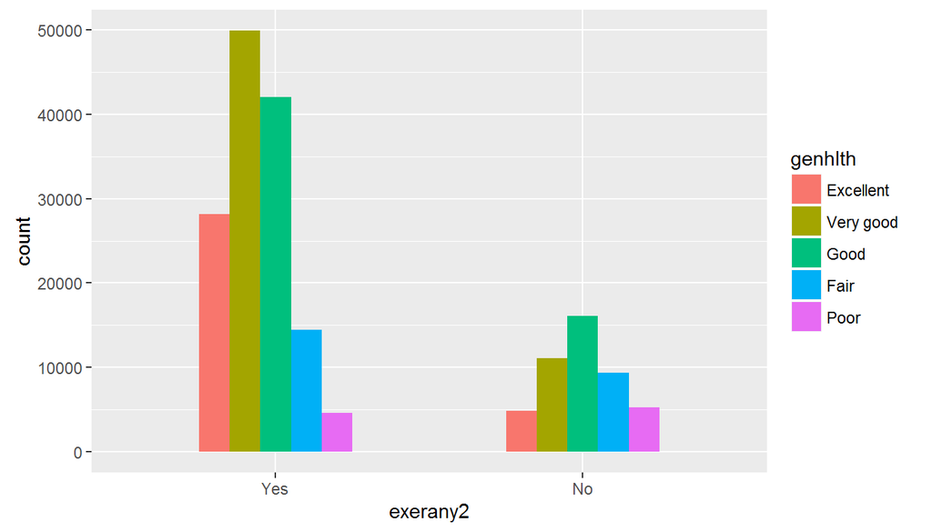

```r
ggplot(data = hAndEMale, aes(x=exerany2, y=count, fill=genhlth)) + geom_bar(stat="identity", width = 0.5, position="dodge")
```

```r
hAndEMale <- hAndEMale %>%
  group_by(genhlth) %>%
  mutate(total=sum(count))

hAndEMale <- hAndEMale %>%
  mutate(prop=count/total)

hAndEMale
```

```
## Source: local data frame [10 x 6]
## Groups: genhlth [5]
##
##      genhlth exerany2    sex count total      prop
##       <fctr>   <fctr> <fctr> <int> <int>     <dbl>
## 1  Excellent      Yes   Male 28193 33009 0.8541004
## 2  Excellent       No   Male  4816 33009 0.1458996
## 3  Very good      Yes   Male 49918 60993 0.8184218
## 4  Very good       No   Male 11075 60993 0.1815782
## 5       Good      Yes   Male 42080 58176 0.7233223
## 6       Good       No   Male 16096 58176 0.2766777
## 7       Fair      Yes   Male 14474 23835 0.6072582
## 8       Fair       No   Male  9361 23835 0.3927418
## 9       Poor      Yes   Male  4548  9797 0.4642237
## 10      Poor       No   Male  5249  9797 0.5357763
```

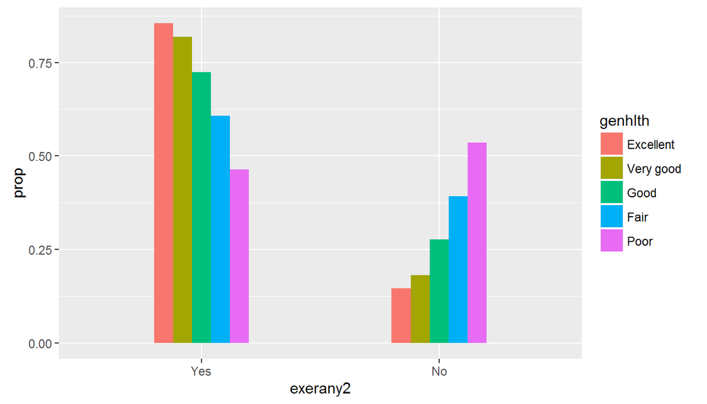

```r
ggplot(hAndEMale, aes(exerany2, prop, fill=genhlth)) + geom_bar(stat="identity", width=0.4, position="dodge")
```

```r
hAndEFemale<- brfss2013 %>%
  filter(!is.na(genhlth) & !is.na(exerany2) & sex == "Female") %>%
  group_by(genhlth, exerany2, sex) %>%
  summarise(count=n())

hAndEFemale
```

```
## Source: local data frame [10 x 4]
## Groups: genhlth, exerany2 [?]
##
##      genhlth exerany2    sex count
##       <fctr>   <fctr> <fctr> <int>
## 1  Excellent      Yes Female 39721
## 2  Excellent       No Female  6637
## 3  Very good      Yes Female 70677
## 4  Very good       No Female 17785
## 5       Good      Yes Female 55015
## 6       Good       No Female 26347
## 7       Fair      Yes Female 20370
## 8       Fair       No Female 17588
## 9       Poor      Yes Female  6393
## 10      Poor       No Female  9607
```

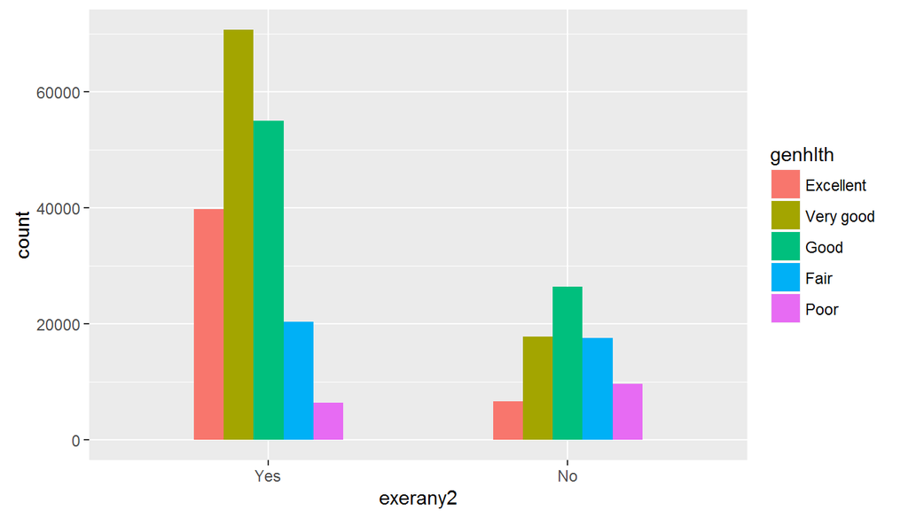

```r
ggplot(data = hAndEFemale, aes(x=exerany2, y=count, fill=genhlth)) + geom_bar(stat="identity", width = 0.5, position="dodge")
```

```r
hAndEFemale <- hAndEMale %>%
  group_by(genhlth) %>%
  mutate(total=sum(count))

hAndEFemale <- hAndEFemale %>%
  mutate(prop=count/total)

hAndEFemale
```

[output not shown]

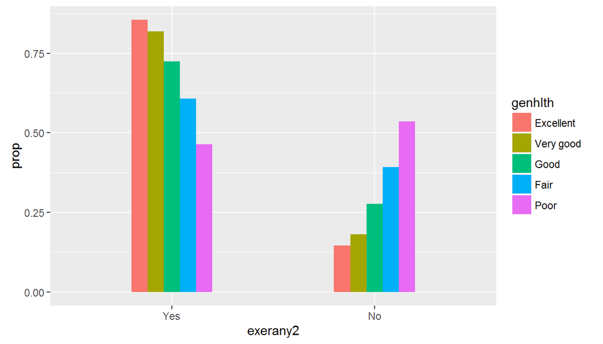

```r
ggplot(hAndEFemale, aes(exerany2, prop, fill=genhlth)) + geom_bar(stat="identity", width=0.4, position="dodge")
```

**Research quesion 3:** Again, to start off, the relevant data is filtered into a dataset called *BCAndH" (Blood cholestrol and Heart attack). NAs are filtered out and records with cvdinfr4 = “Yes” are considered i.e., only records of people who have been diagnosed with heart attack.

```r
BCAndH <- brfss2013 %>%
  filter(!is.na(toldhi2)  & cvdinfr4 == "Yes") %>%
  group_by(toldhi2, cvdinfr4) %>%
  summarise(count=n())
```

The dataset looks like:

```r
BCAndH
```

```
## Source: local data frame [2 x 3]
## Groups: toldhi2 [?]
##
##   toldhi2 cvdinfr4 count
##    <fctr>   <fctr> <int>
## 1     Yes      Yes 19560
## 2      No      Yes  8299
```

A bar graph with toldhi2 on x-axis and count variable on y-axis looks as follows:

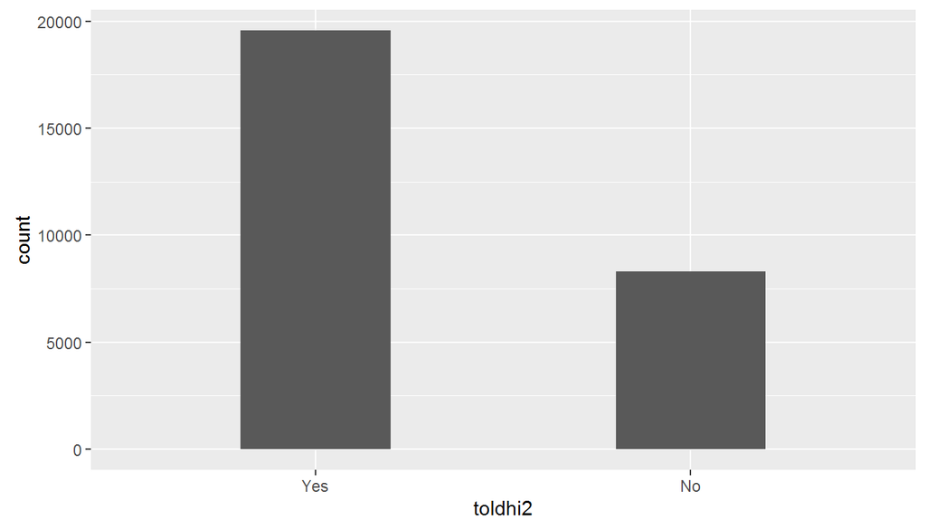

```r
ggplot(data=BCAndH, aes(x=toldhi2, y=count)) + geom_bar(stat="identity", width=0.4)
```

To find out how many of the people who have been diagnosed with heart attack and those who have high blood cholestrol, also smoked at least 100 cigarettes, filtering is done and NAs are filtered out.

```r
BCAndHSmoker <- brfss2013 %>%
   filter(toldhi2=="Yes"  & cvdinfr4 == "Yes" & !is.na(smoke100)) %>%
   group_by(toldhi2, smoke100) %>%
   summarise(count=n())
```

The dataset looks like follows:

```r
BCAndHSmoker
```

```
## Source: local data frame [2 x 3]
## Groups: toldhi2 [?]
##
##   toldhi2 smoke100 count
##    <fctr>   <fctr> <int>
## 1     Yes      Yes 12611
## 2     Yes       No  6435
```

A bar graph with smoke variable on x-axis and count on y-axis looks like:

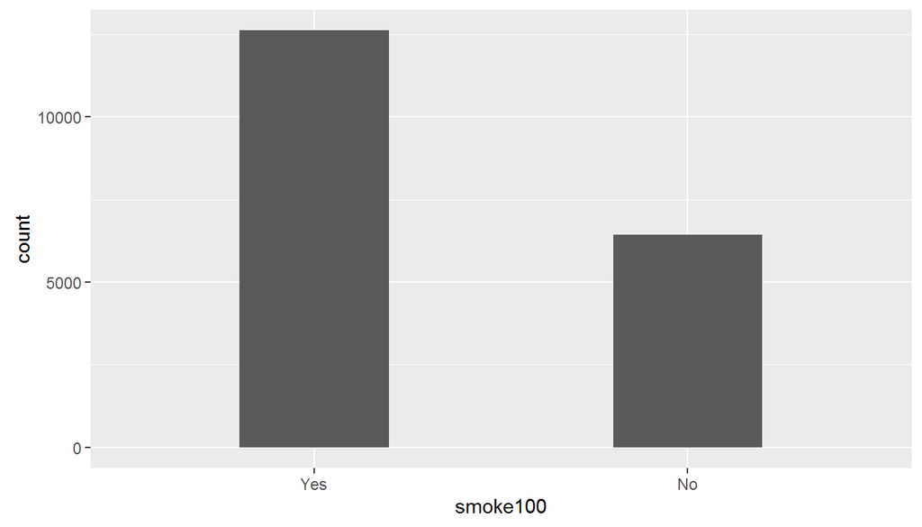

```r
ggplot(BCAndHSmoker, aes(x=smoke100, y=count)) + geom_bar(stat="identity", width = 0.4)
```

It can be seen that a high number of people who smoked at least 100 cigarettes have high blood cholestrol and also have been diagnosed with a heart attack at least once.